# STAT400-Project2

# 4(a):

```r
estimate_pi_modified <- function(seed = 2, iterations = 100000000){
  set.seed(seed)

  x <- runif(n = iterations, min = -1, max =1)

  val_of_g = sqrt(1-x^2)

  pi_over_four = mean(val_of_g)

  pi <- 4 * pi_over_four
  return(pi)
}

estimate_pi_modified()
```

```
[1] 3.14159
```

# 4(b):

```r
estimate_integral <- function(iterations = 1000000) {
  set.seed(2)
  t <- runif(iterations, 0, 2)
  val_of_g <- sqrt(1 + t^2 + t^4)
  (2-0) * mean(val_of_g) # The factor (2-0) comes from the interval length [0,2]
}
estimate_integral()
```

```
[1] 4.197937
```

# 5:

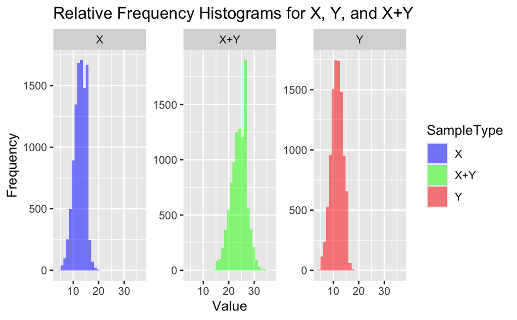

```r
library(ggplot2)
set.seed(2)
X_samples <- rbinom(10000, 21, .6)
Y_samples <- rbinom(10000, 19, .6)
XY_sum_samples <- X_samples + Y_samples

df <- data.frame(
  SampleType = factor(rep(c("X", "Y", "X+Y"), each=10000)),
  Value = c(X_samples, Y_samples, XY_sum_samples)
)

ggplot(df, aes(x=Value, fill=SampleType)) +
  geom_histogram(position="identity", alpha=0.5, bins=30) +
  scale_fill_manual(values=c("blue", "green", "red")) +
  labs(title="Relative Frequency Histograms for X, Y, and X+Y",
       x="Value",
       y="Frequency") +
  facet_wrap(~SampleType, scales="free_y")
```

Given that the distribuion of X+Y closely mirros the anticiapted characteristics of a binomial distribution with parameters 40, 3/5 - specifically, the distribution’s shape, center around the mean of 24, and spread - it can be concluded that the outcomes from the simulation strongly support the hypothesis X+Y~Bin(40, 3/5). This outcome is consistent with theoretical expectations about the sum of independent binomial distributions sharing the same success probability.